# Risk Factor Analysis

## Outcome Variable

**Outcome Variable:** stunted

## Predictor Variables

**Intervention Variable:** mwtkg

**Adjustment Set:**

- arm
- W_mage
- meducyrs
- feducyrs
- single
- brthmon
- W_parity
- delta_W_mage
- delta_meducyrs
- delta_feducyrs
- delta_single
- delta_brthmon
- delta_W_parity

## Stratifying Variables

The analysis was stratified on these variable(s):

- agecat
- studyid
- country

## Data Summary

| agecat | studyid | country | mwtkg | stunted | n_cell | n |
| --- | --- | --- | --- | --- | --- | --- |
| Birth | JiVitA-3 | BANGLADESH | >=58 kg | 0 | 374 | 22432 |
| Birth | JiVitA-3 | BANGLADESH | >=58 kg | 1 | 126 | 22432 |
| Birth | JiVitA-3 | BANGLADESH | <52 kg | 0 | 13634 | 22432 |
| Birth | JiVitA-3 | BANGLADESH | <52 kg | 1 | 6845 | 22432 |
| Birth | JiVitA-3 | BANGLADESH | [52-58) kg | 0 | 1046 | 22432 |
| Birth | JiVitA-3 | BANGLADESH | [52-58) kg | 1 | 407 | 22432 |
| Birth | MAL-ED | BANGLADESH | >=58 kg | 0 | 31 | 222 |
| Birth | MAL-ED | BANGLADESH | >=58 kg | 1 | 7 | 222 |
| Birth | MAL-ED | BANGLADESH | <52 kg | 0 | 114 | 222 |
| Birth | MAL-ED | BANGLADESH | <52 kg | 1 | 29 | 222 |
| Birth | MAL-ED | BANGLADESH | [52-58) kg | 0 | 37 | 222 |
| Birth | MAL-ED | BANGLADESH | [52-58) kg | 1 | 4 | 222 |
| Birth | MAL-ED | BRAZIL | >=58 kg | 0 | 31 | 64 |
| Birth | MAL-ED | BRAZIL | >=58 kg | 1 | 3 | 64 |
| Birth | MAL-ED | BRAZIL | <52 kg | 0 | 11 | 64 |
| Birth | MAL-ED | BRAZIL | <52 kg | 1 | 4 | 64 |
| Birth | MAL-ED | BRAZIL | [52-58) kg | 0 | 13 | 64 |
| Birth | MAL-ED | BRAZIL | [52-58) kg | 1 | 2 | 64 |
| Birth | MAL-ED | INDIA | >=58 kg | 0 | 5 | 43 |
| Birth | MAL-ED | INDIA | >=58 kg | 1 | 1 | 43 |
| Birth | MAL-ED | INDIA | <52 kg | 0 | 24 | 43 |
| Birth | MAL-ED | INDIA | <52 kg | 1 | 5 | 43 |
| Birth | MAL-ED | INDIA | [52-58) kg | 0 | 5 | 43 |
| Birth | MAL-ED | INDIA | [52-58) kg | 1 | 3 | 43 |
| Birth | MAL-ED | NEPAL | >=58 kg | 0 | 9 | 27 |
| Birth | MAL-ED | NEPAL | >=58 kg | 1 | 0 | 27 |
| Birth | MAL-ED | NEPAL | <52 kg | 0 | 6 | 27 |
| Birth | MAL-ED | NEPAL | <52 kg | 1 | 2 | 27 |
| Birth | MAL-ED | NEPAL | [52-58) kg | 0 | 10 | 27 |
| Birth | MAL-ED | NEPAL | [52-58) kg | 1 | 0 | 27 |

[output cut: 240 more lines]

The following strata were considered:

- agecat: 24 months, studyid: JiVitA-3, country: BANGLADESH
- agecat: 24 months, studyid: LCNI-5, country: MALAWI
- agecat: 24 months, studyid: MAL-ED, country: BANGLADESH
- agecat: 24 months, studyid: MAL-ED, country: BRAZIL
- agecat: 24 months, studyid: MAL-ED, country: INDIA
- agecat: 24 months, studyid: MAL-ED, country: NEPAL
- agecat: 24 months, studyid: MAL-ED, country: PERU
- agecat: 24 months, studyid: MAL-ED, country: SOUTH AFRICA
- agecat: 24 months, studyid: MAL-ED, country: TANZANIA, UNITED REPUBLIC OF
- agecat: 24 months, studyid: NIH-Birth, country: BANGLADESH
- agecat: 24 months, studyid: NIH-Crypto, country: BANGLADESH
- agecat: 24 months, studyid: PROBIT, country: BELARUS
- agecat: 24 months, studyid: PROVIDE, country: BANGLADESH
- agecat: 24 months, studyid: TanzaniaChild2, country: TANZANIA, UNITED REPUBLIC OF
- agecat: 24 months, studyid: ZVITAMBO, country: ZIMBABWE
- agecat: 6 months, studyid: JiVitA-3, country: BANGLADESH
- agecat: 6 months, studyid: LCNI-5, country: MALAWI
- agecat: 6 months, studyid: MAL-ED, country: BANGLADESH
- agecat: 6 months, studyid: MAL-ED, country: BRAZIL
- agecat: 6 months, studyid: MAL-ED, country: INDIA
- agecat: 6 months, studyid: MAL-ED, country: NEPAL
- agecat: 6 months, studyid: MAL-ED, country: PERU
- agecat: 6 months, studyid: MAL-ED, country: SOUTH AFRICA
- agecat: 6 months, studyid: MAL-ED, country: TANZANIA, UNITED REPUBLIC OF
- agecat: 6 months, studyid: NIH-Birth, country: BANGLADESH
- agecat: 6 months, studyid: NIH-Crypto, country: BANGLADESH
- agecat: 6 months, studyid: PROBIT, country: BELARUS
- agecat: 6 months, studyid: PROVIDE, country: BANGLADESH
- agecat: 6 months, studyid: SAS-CompFeed, country: INDIA
- agecat: 6 months, studyid: TanzaniaChild2, country: TANZANIA, UNITED REPUBLIC OF
- agecat: 6 months, studyid: ZVITAMBO, country: ZIMBABWE
- agecat: Birth, studyid: JiVitA-3, country: BANGLADESH
- agecat: Birth, studyid: MAL-ED, country: BANGLADESH
- agecat: Birth, studyid: MAL-ED, country: BRAZIL
- agecat: Birth, studyid: MAL-ED, country: INDIA
- agecat: Birth, studyid: MAL-ED, country: NEPAL
- agecat: Birth, studyid: MAL-ED, country: PERU
- agecat: Birth, studyid: MAL-ED, country: SOUTH AFRICA
- agecat: Birth, studyid: MAL-ED, country: TANZANIA, UNITED REPUBLIC OF
- agecat: Birth, studyid: NIH-Birth, country: BANGLADESH
- agecat: Birth, studyid: NIH-Crypto, country: BANGLADESH
- agecat: Birth, studyid: PROBIT, country: BELARUS
- agecat: Birth, studyid: PROVIDE, country: BANGLADESH
- agecat: Birth, studyid: SAS-CompFeed, country: INDIA
- agecat: Birth, studyid: ZVITAMBO, country: ZIMBABWE

### Dropped Strata

Some strata were dropped due to rare outcomes:

- agecat: Birth, studyid: MAL-ED, country: BANGLADESH
- agecat: Birth, studyid: MAL-ED, country: BRAZIL
- agecat: Birth, studyid: MAL-ED, country: INDIA
- agecat: Birth, studyid: MAL-ED, country: NEPAL
- agecat: Birth, studyid: MAL-ED, country: SOUTH AFRICA
- agecat: Birth, studyid: MAL-ED, country: TANZANIA, UNITED REPUBLIC OF
- agecat: Birth, studyid: PROBIT, country: BELARUS
- agecat: Birth, studyid: PROVIDE, country: BANGLADESH
- agecat: 6 months, studyid: MAL-ED, country: BANGLADESH
- agecat: 6 months, studyid: MAL-ED, country: BRAZIL
- agecat: 6 months, studyid: MAL-ED, country: INDIA
- agecat: 6 months, studyid: MAL-ED, country: NEPAL
- agecat: 24 months, studyid: MAL-ED, country: BRAZIL
- agecat: 24 months, studyid: TanzaniaChild2, country: TANZANIA, UNITED REPUBLIC OF

## Methods Detail

We’re interested in the causal parameters $E[Y_a]$ for all values of $a \in \mathcal{A}$. These parameters represent the mean outcome if, possibly contrary to fact, we intervened to set all units to have $A=a$. Under the randomization and positivity assumptions, these are identified by the statistical parameters $\psi_a=E_W[E_{Y|A,W}(Y|A=a,W)]$. In addition, we’re interested in the mean of $Y$, $E[Y]$ under no intervention (the observed mean). We will estimate these parameters by using SuperLearner to fit the relevant likelihood factors – $E_{Y|A,W}(Y|A=a,W)$ and $p(A=a|W)$, and then updating our likelihood fit using a joint TMLE.

For unadjusted analyses ($W=\{\}$), initial likelihoods were estimated using Lrnr_glm to estimate the simple $E(Y|A)$ and Lrnr_mean to estimate $p(A)$. For adjusted analyses, a small library containing Lrnr_glmnet, Lrnr_xgboost, and Lrnr_mean was used.

Having estimated these parameters, we will then use the delta method to estimate relative risks and attributable risks relative to a prespecified baseline level of $A$.

# Results Detail

## Results Plots

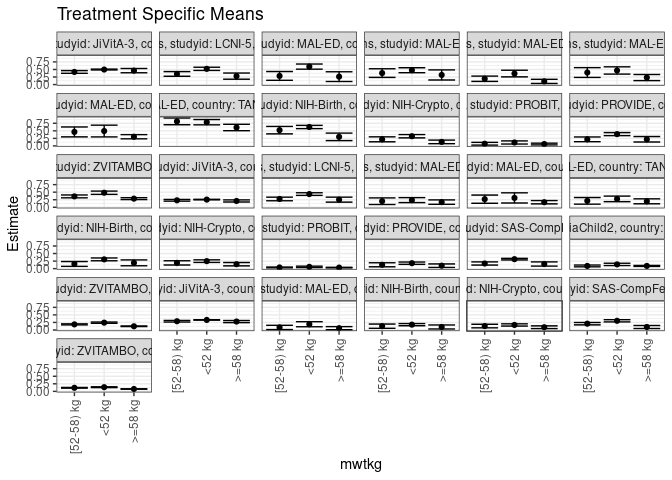

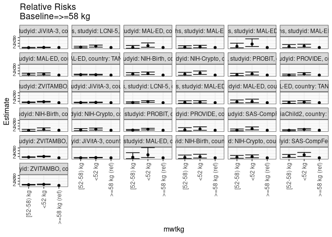

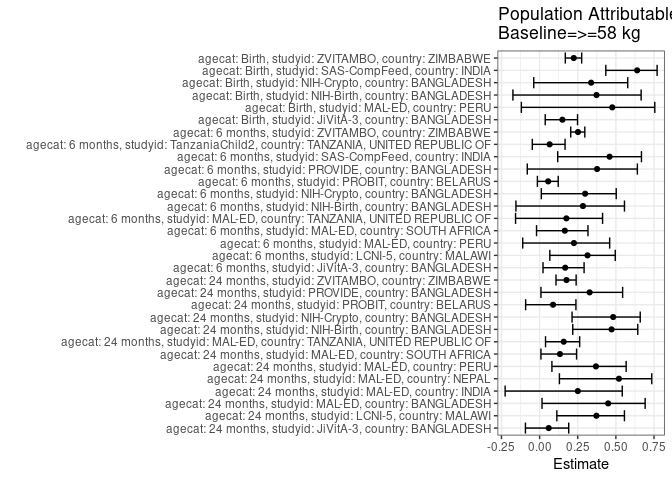

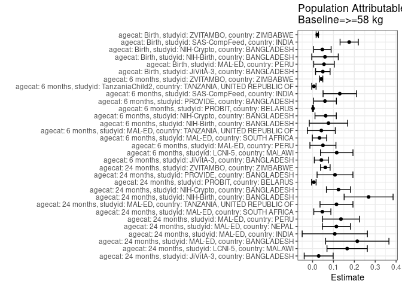

## Results Table

### Parameter: TSM

| agecat | studyid | country | intervention_level | baseline_level | estimate | ci_lower | ci_upper |
| --- | --- | --- | --- | --- | --- | --- | --- |
| Birth | JiVitA-3 | BANGLADESH | >=58 kg | NA | 0.2797846 | 0.2446074 | 0.3149617 |
| Birth | JiVitA-3 | BANGLADESH | <52 kg | NA | 0.3329127 | 0.3253312 | 0.3404942 |
| Birth | JiVitA-3 | BANGLADESH | [52-58) kg | NA | 0.2900318 | 0.2639072 | 0.3161564 |
| Birth | MAL-ED | PERU | >=58 kg | NA | 0.0602410 | 0.0089399 | 0.1115420 |
| Birth | MAL-ED | PERU | <52 kg | NA | 0.1904762 | 0.1063160 | 0.2746364 |
| Birth | MAL-ED | PERU | [52-58) kg | NA | 0.0847458 | 0.0135236 | 0.1559679 |
| Birth | NIH-Birth | BANGLADESH | >=58 kg | NA | 0.1000000 | 0.0342067 | 0.1657933 |
| Birth | NIH-Birth | BANGLADESH | <52 kg | NA | 0.1768707 | 0.1412299 | 0.2125116 |
| Birth | NIH-Birth | BANGLADESH | [52-58) kg | NA | 0.1264368 | 0.0565444 | 0.1963292 |
| Birth | NIH-Crypto | BANGLADESH | >=58 kg | NA | 0.0917404 | 0.0470648 | 0.1364161 |
| Birth | NIH-Crypto | BANGLADESH | <52 kg | NA | 0.1672856 | 0.1301839 | 0.2043873 |
| Birth | NIH-Crypto | BANGLADESH | [52-58) kg | NA | 0.1305654 | 0.0712455 | 0.1898852 |
| Birth | SAS-CompFeed | INDIA | >=58 kg | NA | 0.0989011 | 0.0494314 | 0.1483708 |
| Birth | SAS-CompFeed | INDIA | <52 kg | NA | 0.3045311 | 0.2684154 | 0.3406468 |
| Birth | SAS-CompFeed | INDIA | [52-58) kg | NA | 0.2091837 | 0.1698398 | 0.2485275 |
| Birth | ZVITAMBO | ZIMBABWE | >=58 kg | NA | 0.0784335 | 0.0714080 | 0.0854589 |
| Birth | ZVITAMBO | ZIMBABWE | <52 kg | NA | 0.1375673 | 0.1232567 | 0.1518779 |
| Birth | ZVITAMBO | ZIMBABWE | [52-58) kg | NA | 0.1176530 | 0.1056323 | 0.1296737 |
| 6 months | JiVitA-3 | BANGLADESH | >=58 kg | NA | 0.2092698 | 0.1749052 | 0.2436344 |
| 6 months | JiVitA-3 | BANGLADESH | <52 kg | NA | 0.2545726 | 0.2460968 | 0.2630485 |
| 6 months | JiVitA-3 | BANGLADESH | [52-58) kg | NA | 0.2307134 | 0.2031070 | 0.2583198 |
| 6 months | LCNI-5 | MALAWI | >=58 kg | NA | 0.2523163 | 0.1701671 | 0.3344656 |
| 6 months | LCNI-5 | MALAWI | <52 kg | NA | 0.4372704 | 0.3940827 | 0.4804580 |
| 6 months | LCNI-5 | MALAWI | [52-58) kg | NA | 0.2753227 | 0.2150803 | 0.3355651 |
| 6 months | MAL-ED | PERU | >=58 kg | NA | 0.1709517 | 0.0978839 | 0.2440196 |
| 6 months | MAL-ED | PERU | <52 kg | NA | 0.2370179 | 0.1548692 | 0.3191666 |
| 6 months | MAL-ED | PERU | [52-58) kg | NA | 0.2012524 | 0.0924588 | 0.3100459 |
| 6 months | MAL-ED | SOUTH AFRICA | >=58 kg | NA | 0.1675978 | 0.1127706 | 0.2224250 |
| 6 months | MAL-ED | SOUTH AFRICA | <52 kg | NA | 0.3103448 | 0.1416269 | 0.4790627 |
| 6 months | MAL-ED | SOUTH AFRICA | [52-58) kg | NA | 0.2682927 | 0.1323978 | 0.4041876 |

[output cut: 63 more lines]

### Parameter: E(Y)

| agecat | studyid | country | intervention_level | baseline_level | estimate | ci_lower | ci_upper |
| --- | --- | --- | --- | --- | --- | --- | --- |
| Birth | JiVitA-3 | BANGLADESH | NA | NA | 0.3289051 | 0.3215448 | 0.3362655 |
| Birth | MAL-ED | PERU | NA | NA | 0.1150442 | 0.0733525 | 0.1567360 |
| Birth | NIH-Birth | BANGLADESH | NA | NA | 0.1595395 | 0.1304091 | 0.1886699 |
| Birth | NIH-Crypto | BANGLADESH | NA | NA | 0.1385460 | 0.1134505 | 0.1636414 |
| Birth | SAS-CompFeed | INDIA | NA | NA | 0.2742718 | 0.2403806 | 0.3081631 |
| Birth | ZVITAMBO | ZIMBABWE | NA | NA | 0.1010788 | 0.0954534 | 0.1067041 |
| 6 months | JiVitA-3 | BANGLADESH | NA | NA | 0.2514582 | 0.2433372 | 0.2595791 |
| 6 months | LCNI-5 | MALAWI | NA | NA | 0.3679809 | 0.3352903 | 0.4006715 |
| 6 months | MAL-ED | PERU | NA | NA | 0.2205882 | 0.1712211 | 0.2699554 |
| 6 months | MAL-ED | SOUTH AFRICA | NA | NA | 0.2008032 | 0.1509453 | 0.2506612 |
| 6 months | MAL-ED | TANZANIA, UNITED REPUBLIC OF | NA | NA | 0.2388664 | 0.1855834 | 0.2921494 |
| 6 months | NIH-Birth | BANGLADESH | NA | NA | 0.2681564 | 0.2306532 | 0.3056597 |
| 6 months | NIH-Crypto | BANGLADESH | NA | NA | 0.2097902 | 0.1799252 | 0.2396552 |
| 6 months | PROBIT | BELARUS | NA | NA | 0.0368896 | 0.0278229 | 0.0459564 |
| 6 months | PROVIDE | BANGLADESH | NA | NA | 0.1575456 | 0.1284434 | 0.1866478 |
| 6 months | SAS-CompFeed | INDIA | NA | NA | 0.2839970 | 0.2655949 | 0.3023990 |
| 6 months | TanzaniaChild2 | TANZANIA, UNITED REPUBLIC OF | NA | NA | 0.0965309 | 0.0835493 | 0.1095126 |
| 6 months | ZVITAMBO | ZIMBABWE | NA | NA | 0.1640417 | 0.1560523 | 0.1720310 |
| 24 months | JiVitA-3 | BANGLADESH | NA | NA | 0.4910166 | 0.4779105 | 0.5041227 |
| 24 months | LCNI-5 | MALAWI | NA | NA | 0.4446367 | 0.4040904 | 0.4851830 |
| 24 months | MAL-ED | BANGLADESH | NA | NA | 0.4764151 | 0.4090254 | 0.5438047 |
| 24 months | MAL-ED | INDIA | NA | NA | 0.4247788 | 0.3601902 | 0.4893673 |
| 24 months | MAL-ED | NEPAL | NA | NA | 0.2192982 | 0.1654718 | 0.2731246 |
| 24 months | MAL-ED | PERU | NA | NA | 0.3681592 | 0.3013164 | 0.4350020 |
| 24 months | MAL-ED | SOUTH AFRICA | NA | NA | 0.3504274 | 0.2891665 | 0.4116882 |
| 24 months | MAL-ED | TANZANIA, UNITED REPUBLIC OF | NA | NA | 0.7242991 | 0.6642873 | 0.7843108 |
| 24 months | NIH-Birth | BANGLADESH | NA | NA | 0.5687646 | 0.5218455 | 0.6156837 |
| 24 months | NIH-Crypto | BANGLADESH | NA | NA | 0.2568093 | 0.2190047 | 0.2946140 |
| 24 months | PROBIT | BELARUS | NA | NA | 0.0680289 | 0.0409200 | 0.0951378 |
| 24 months | PROVIDE | BANGLADESH | NA | NA | 0.3275563 | 0.2892291 | 0.3658836 |
| 24 months | ZVITAMBO | ZIMBABWE | NA | NA | 0.3469773 | 0.3235580 | 0.3703967 |

### Parameter: RR

| agecat | studyid | country | intervention_level | baseline_level | estimate | ci_lower | ci_upper |
| --- | --- | --- | --- | --- | --- | --- | --- |
| Birth | JiVitA-3 | BANGLADESH | >=58 kg | >=58 kg | 1.0000000 | 1.0000000 | 1.000000 |
| Birth | JiVitA-3 | BANGLADESH | <52 kg | >=58 kg | 1.1898895 | 1.0474557 | 1.351692 |
| Birth | JiVitA-3 | BANGLADESH | [52-58) kg | >=58 kg | 1.0366254 | 0.8934986 | 1.202679 |
| Birth | MAL-ED | PERU | >=58 kg | >=58 kg | 1.0000000 | 1.0000000 | 1.000000 |
| Birth | MAL-ED | PERU | <52 kg | >=58 kg | 3.1619048 | 1.2114019 | 8.252952 |
| Birth | MAL-ED | PERU | [52-58) kg | >=58 kg | 1.4067797 | 0.4252149 | 4.654186 |
| Birth | NIH-Birth | BANGLADESH | >=58 kg | >=58 kg | 1.0000000 | 1.0000000 | 1.000000 |
| Birth | NIH-Birth | BANGLADESH | <52 kg | >=58 kg | 1.7687075 | 0.8888286 | 3.519606 |
| Birth | NIH-Birth | BANGLADESH | [52-58) kg | >=58 kg | 1.2643678 | 0.5353913 | 2.985902 |
| Birth | NIH-Crypto | BANGLADESH | >=58 kg | >=58 kg | 1.0000000 | 1.0000000 | 1.000000 |
| Birth | NIH-Crypto | BANGLADESH | <52 kg | >=58 kg | 1.8234665 | 1.0673604 | 3.115190 |
| Birth | NIH-Crypto | BANGLADESH | [52-58) kg | >=58 kg | 1.4232038 | 0.7319597 | 2.767241 |
| Birth | SAS-CompFeed | INDIA | >=58 kg | >=58 kg | 1.0000000 | 1.0000000 | 1.000000 |
| Birth | SAS-CompFeed | INDIA | <52 kg | >=58 kg | 3.0791476 | 1.9560693 | 4.847042 |
| Birth | SAS-CompFeed | INDIA | [52-58) kg | >=58 kg | 2.1150794 | 1.3057415 | 3.426069 |
| Birth | ZVITAMBO | ZIMBABWE | >=58 kg | >=58 kg | 1.0000000 | 1.0000000 | 1.000000 |
| Birth | ZVITAMBO | ZIMBABWE | <52 kg | >=58 kg | 1.7539364 | 1.5290738 | 2.011867 |
| Birth | ZVITAMBO | ZIMBABWE | [52-58) kg | >=58 kg | 1.5000361 | 1.3095710 | 1.718203 |
| 6 months | JiVitA-3 | BANGLADESH | >=58 kg | >=58 kg | 1.0000000 | 1.0000000 | 1.000000 |
| 6 months | JiVitA-3 | BANGLADESH | <52 kg | >=58 kg | 1.2164804 | 1.0316087 | 1.434483 |
| 6 months | JiVitA-3 | BANGLADESH | [52-58) kg | >=58 kg | 1.1024687 | 0.9009585 | 1.349049 |
| 6 months | LCNI-5 | MALAWI | >=58 kg | >=58 kg | 1.0000000 | 1.0000000 | 1.000000 |
| 6 months | LCNI-5 | MALAWI | <52 kg | >=58 kg | 1.7330244 | 1.2336170 | 2.434608 |
| 6 months | LCNI-5 | MALAWI | [52-58) kg | >=58 kg | 1.0911806 | 0.7366528 | 1.616331 |
| 6 months | MAL-ED | PERU | >=58 kg | >=58 kg | 1.0000000 | 1.0000000 | 1.000000 |
| 6 months | MAL-ED | PERU | <52 kg | >=58 kg | 1.3864609 | 0.7960653 | 2.414719 |
| 6 months | MAL-ED | PERU | [52-58) kg | >=58 kg | 1.1772468 | 0.5908048 | 2.345800 |
| 6 months | MAL-ED | SOUTH AFRICA | >=58 kg | >=58 kg | 1.0000000 | 1.0000000 | 1.000000 |
| 6 months | MAL-ED | SOUTH AFRICA | <52 kg | >=58 kg | 1.8517241 | 0.9818013 | 3.492440 |
| 6 months | MAL-ED | SOUTH AFRICA | [52-58) kg | >=58 kg | 1.6008130 | 0.8759360 | 2.925559 |

[output cut: 63 more lines]

### Parameter: PAR

| agecat | studyid | country | intervention_level | baseline_level | estimate | ci_lower | ci_upper |
| --- | --- | --- | --- | --- | --- | --- | --- |
| Birth | JiVitA-3 | BANGLADESH | >=58 kg | NA | 0.0491206 | 0.0143247 | 0.0839165 |
| Birth | MAL-ED | PERU | >=58 kg | NA | 0.0548033 | 0.0054382 | 0.1041683 |
| Birth | NIH-Birth | BANGLADESH | >=58 kg | NA | 0.0595395 | -0.0040073 | 0.1230863 |
| Birth | NIH-Crypto | BANGLADESH | >=58 kg | NA | 0.0468055 | 0.0047499 | 0.0888611 |
| Birth | SAS-CompFeed | INDIA | >=58 kg | NA | 0.1753707 | 0.1316984 | 0.2190431 |
| Birth | ZVITAMBO | ZIMBABWE | >=58 kg | NA | 0.0226453 | 0.0171023 | 0.0281884 |
| 6 months | JiVitA-3 | BANGLADESH | >=58 kg | NA | 0.0421884 | 0.0084459 | 0.0759308 |
| 6 months | LCNI-5 | MALAWI | >=58 kg | NA | 0.1156645 | 0.0378839 | 0.1934452 |
| 6 months | MAL-ED | PERU | >=58 kg | NA | 0.0496365 | -0.0126962 | 0.1119692 |
| 6 months | MAL-ED | SOUTH AFRICA | >=58 kg | NA | 0.0332054 | -0.0009987 | 0.0674096 |
| 6 months | MAL-ED | TANZANIA, UNITED REPUBLIC OF | >=58 kg | NA | 0.0419224 | -0.0250468 | 0.1088916 |
| 6 months | NIH-Birth | BANGLADESH | >=58 kg | NA | 0.0761869 | -0.0157291 | 0.1681030 |
| 6 months | NIH-Crypto | BANGLADESH | >=58 kg | NA | 0.0626296 | 0.0115877 | 0.1136714 |
| 6 months | PROBIT | BELARUS | >=58 kg | NA | 0.0020752 | -0.0003688 | 0.0045193 |
| 6 months | PROVIDE | BANGLADESH | >=58 kg | NA | 0.0593936 | 0.0046669 | 0.1141202 |
| 6 months | SAS-CompFeed | INDIA | >=58 kg | NA | 0.1303020 | 0.0502833 | 0.2103207 |
| 6 months | TanzaniaChild2 | TANZANIA, UNITED REPUBLIC OF | >=58 kg | NA | 0.0063421 | -0.0040292 | 0.0167134 |
| 6 months | ZVITAMBO | ZIMBABWE | >=58 kg | NA | 0.0412807 | 0.0335167 | 0.0490447 |
| 24 months | JiVitA-3 | BANGLADESH | >=58 kg | NA | 0.0292781 | -0.0401038 | 0.0986600 |
| 24 months | LCNI-5 | MALAWI | >=58 kg | NA | 0.1656346 | 0.0690691 | 0.2622000 |
| 24 months | MAL-ED | BANGLADESH | >=58 kg | NA | 0.2141013 | 0.0625426 | 0.3656600 |
| 24 months | MAL-ED | INDIA | >=58 kg | NA | 0.1064240 | -0.0497519 | 0.2625999 |
| 24 months | MAL-ED | NEPAL | >=58 kg | NA | 0.1140351 | 0.0470193 | 0.1810508 |
| 24 months | MAL-ED | PERU | >=58 kg | NA | 0.1359839 | 0.0474296 | 0.2245383 |
| 24 months | MAL-ED | SOUTH AFRICA | >=58 kg | NA | 0.0467479 | 0.0058558 | 0.0876399 |
| 24 months | MAL-ED | TANZANIA, UNITED REPUBLIC OF | >=58 kg | NA | 0.1145430 | 0.0356875 | 0.1933984 |
| 24 months | NIH-Birth | BANGLADESH | >=58 kg | NA | 0.2683620 | 0.1511583 | 0.3855656 |
| 24 months | NIH-Crypto | BANGLADESH | >=58 kg | NA | 0.1238752 | 0.0663136 | 0.1814368 |
| 24 months | PROBIT | BELARUS | >=58 kg | NA | 0.0059908 | -0.0049113 | 0.0168929 |
| 24 months | PROVIDE | BANGLADESH | >=58 kg | NA | 0.1074310 | 0.0215993 | 0.1932626 |
| 24 months | ZVITAMBO | ZIMBABWE | >=58 kg | NA | 0.0611178 | 0.0381984 | 0.0840372 |

### Parameter: PAF

| agecat | studyid | country | intervention_level | baseline_level | estimate | ci_lower | ci_upper |
| --- | --- | --- | --- | --- | --- | --- | --- |
| Birth | JiVitA-3 | BANGLADESH | >=58 kg | NA | 0.1493457 | 0.0368361 | 0.2487128 |
| Birth | MAL-ED | PERU | >=58 kg | NA | 0.4763670 | -0.1196867 | 0.7551176 |
| Birth | NIH-Birth | BANGLADESH | >=58 kg | NA | 0.3731959 | -0.1749439 | 0.6656152 |
| Birth | NIH-Crypto | BANGLADESH | >=58 kg | NA | 0.3378338 | -0.0385182 | 0.5777984 |
| Birth | SAS-CompFeed | INDIA | >=58 kg | NA | 0.6394048 | 0.4340269 | 0.7702561 |
| Birth | ZVITAMBO | ZIMBABWE | >=58 kg | NA | 0.2240362 | 0.1684972 | 0.2758656 |
| 6 months | JiVitA-3 | BANGLADESH | >=58 kg | NA | 0.1677748 | 0.0223092 | 0.2915973 |
| 6 months | LCNI-5 | MALAWI | >=58 kg | NA | 0.3143222 | 0.0670037 | 0.4960815 |
| 6 months | MAL-ED | PERU | >=58 kg | NA | 0.2250188 | -0.1108006 | 0.4593127 |
| 6 months | MAL-ED | SOUTH AFRICA | >=58 kg | NA | 0.1653631 | -0.0200531 | 0.3170760 |
| 6 months | MAL-ED | TANZANIA, UNITED REPUBLIC OF | >=58 kg | NA | 0.1755058 | -0.1575667 | 0.4127417 |
| 6 months | NIH-Birth | BANGLADESH | >=58 kg | NA | 0.2841138 | -0.1552017 | 0.5563606 |
| 6 months | NIH-Crypto | BANGLADESH | >=58 kg | NA | 0.2985342 | 0.0112655 | 0.5023393 |
| 6 months | PROBIT | BELARUS | >=58 kg | NA | 0.0562554 | -0.0144925 | 0.1220694 |
| 6 months | PROVIDE | BANGLADESH | >=58 kg | NA | 0.3769929 | -0.0808722 | 0.6409031 |
| 6 months | SAS-CompFeed | INDIA | >=58 kg | NA | 0.4588147 | 0.1186094 | 0.6677052 |
| 6 months | TanzaniaChild2 | TANZANIA, UNITED REPUBLIC OF | >=58 kg | NA | 0.0657002 | -0.0478198 | 0.1669215 |
| 6 months | ZVITAMBO | ZIMBABWE | >=58 kg | NA | 0.2516477 | 0.2040029 | 0.2964407 |
| 24 months | JiVitA-3 | BANGLADESH | >=58 kg | NA | 0.0596275 | -0.0928480 | 0.1908295 |
| 24 months | LCNI-5 | MALAWI | >=58 kg | NA | 0.3725166 | 0.1129050 | 0.5561519 |
| 24 months | MAL-ED | BANGLADESH | >=58 kg | NA | 0.4494007 | 0.0158550 | 0.6919564 |
| 24 months | MAL-ED | INDIA | >=58 kg | NA | 0.2505399 | -0.2259783 | 0.5418431 |
| 24 months | MAL-ED | NEPAL | >=58 kg | NA | 0.5200000 | 0.1299938 | 0.7351743 |
| 24 months | MAL-ED | PERU | >=58 kg | NA | 0.3693617 | 0.0806717 | 0.5673965 |
| 24 months | MAL-ED | SOUTH AFRICA | >=58 kg | NA | 0.1334024 | 0.0087258 | 0.2423980 |
| 24 months | MAL-ED | TANZANIA, UNITED REPUBLIC OF | >=58 kg | NA | 0.1581432 | 0.0388790 | 0.2626081 |
| 24 months | NIH-Birth | BANGLADESH | >=58 kg | NA | 0.4718331 | 0.2172492 | 0.6436155 |
| 24 months | NIH-Crypto | BANGLADESH | >=58 kg | NA | 0.4823627 | 0.2127752 | 0.6596292 |
| 24 months | PROBIT | BELARUS | >=58 kg | NA | 0.0880621 | -0.0915278 | 0.2381040 |
| 24 months | PROVIDE | BANGLADESH | >=58 kg | NA | 0.3279771 | 0.0089040 | 0.5443279 |
| 24 months | ZVITAMBO | ZIMBABWE | >=58 kg | NA | 0.1761434 | 0.1075124 | 0.2394968 |